# lab_9

b06208016楊鎧綾

November 9, 2018

## 11.18

### a

```r
2/sqrt(100)
```

```
## [1] 0.2
```

```r
2/sqrt(64)
```

```
## [1] 0.25
```

**the standard error of the mean of women is 0.2**  
which is smaller than the standard error of the mean of men, which is 0.25 is because **the sample of the women is bigger than the men**  
the bigger the sample size the smaller the standard error if standard deviation is the same

### b

```r
sqrt((2^2)/100+(2^2)/64)
```

```
## [1] 0.3201562
```

**standard error of difference between women and men is 0.3201562**

## 11.32

### a

```r
xbar1=4.5
se1=1.6/sqrt(25)
t1=2.06 #以n-1=24,根據查表得知
ci.lower=xbar1-t1*se1
ci.high=xbar1+t1*se1
ci.lower;ci.high
```

```
## [1] 3.8408
```

```
## [1] 5.1592
```

**the confidence interval under 95% confidence level of the df=24 is (3.8408,5.1592)**

### b

```r
xbar2=8.1
se2=1.8/sqrt(23)
t2=2.07 #以df=22,根據查表得知
ci.lower2=xbar2-t2*se2
ci.high2=xbar2+t2*se2
ci.lower2;ci.high2
```

```
## [1] 7.323075
```

```
## [1] 8.876925
```

**the confidence interval under 95% confidence level of the df=22 is (7.323075,8.876925)**

### c

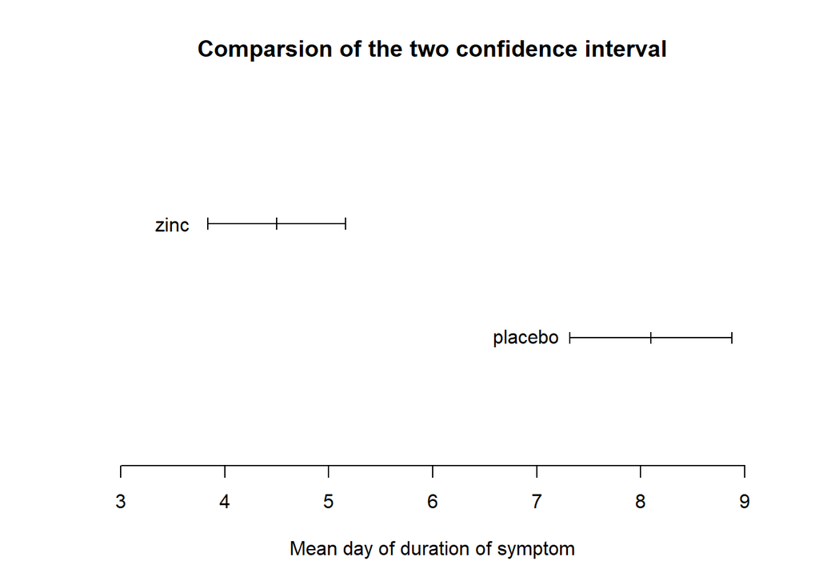

```r
plot(c(0,3),type='n',xlim=c(3,9),xlab='Mean day of duration of symptom',ylab='',axes=F,
     main='Comparsion of the two confidence interval')

lines(c(3.84,5.16),c(2,2))
text(3.5,2,labels='zinc')
lines(c(3.84,3.84),c(1.95,2.05))
lines(c(5.16,5.16),c(1.95,2.05))
lines(c(4.5,4.5),c(1.95,2.05))

lines(c(7.32,8.88),c(1,1))
text(6.9,1,labels='placebo')
lines(c(7.32,7.32),c(0.95,1.05))
lines(c(8.88,8.88),c(0.95,1.05))
lines(c(8.1,8.1),c(0.95,1.05))

axis(1)
```

### d

**從ab小題的信賴區間來看，兩者的感冒持續時間的信賴區間沒有交集，c小題畫圖呈現就更加明顯沒有交集了，而且zinc的整個信賴區間數字都比placebo小，所以可以說明用zinc是比較有效可以減少感冒持續時間的**

### e

在連續資料的信賴區間預估中，必須符合以下其中一個條件  
1.random selected and normal distribution  
2.random selected sample bigger than 30  
**而此題不管是zinc還是plavebo的抽樣樣本數小於30，因此必需要是常態分部，才可以這樣估計出信賴區間**

## 11.50

### a

```r
dbar=1.8
se=2.1/sqrt(20)
t=2.09 #以df=19,confidence level is95%,根據查表得知
ci.lower=dbar-t*se
ci.high=dbar+t*se
ci.lower;ci.high
```

```
## [1] 0.8185898
```

```
## [1] 2.78141
```

the confidence interval for the mean difference of desired and actual height under 95% confidence level of the df=19 is (0.82,2.78)  
which means there are 95% the randomly selected sample mean will be in the interval, or 95% the sampling confidence interval will contain the population parameter

### b

**因為此題樣本數為20小於30，因此母體資料必需要是常態分部，而且樣本資料不可有嚴重的skewed或者有outline，才可以這樣估計出信賴區間**

### c

the confidence interval for the mean difference of desired and actual height under 95% confidence level of the df=19 is (0.82,2.78)  
which means there are 95% the randomly selected sample mean will be in the interval, or 95% the sampling confidence interval will contain the population parameter  
does not mean all the women between the age want to be taller  
那樣的說法太肯定，誤解了信心水準與信賴區間的意義

### d

此題不適用approximate 95% interval confidence intervals，因為樣本數不夠大  
如果是使用查表的話t值是2.09,但用approximate的話t值是2,會造成信賴區間的估計較窄，造成估計上並不是比較保守

## 11.60

### a

```r
exer_t<-c(62,72,60,63,75,64,60,52,64,80,68,64)
exer_f<-c(72,84,66,72,62,84,76,60)
t.test(exer_t,exer_f,alternative="two.sided",paired = F,var.equal = F,conf.level = 0.95)
```

```
##
##  Welch Two Sample t-test
##
## data:  exer_t and exer_f
## t = -1.7156, df = 13.014, p-value = 0.1099
## alternative hypothesis: true difference in means is not equal to 0
## 95 percent confidence interval:
##  -15.060720   1.727387
## sample estimates:
## mean of x mean of y
##  65.33333  72.00000
```

the 95% confidence interval for the difference in mean is(-15.06,1.73)  
because the sample size is smaller than 30, so the distribution must be normal distribution, if want to calculate the confidence interval

### b

```r
t.test(exer_t,exer_f,alternative="two.sided",paired = F,var.equal = T,conf.level = 0.95)
```

```
##
##  Two Sample t-test
##
## data:  exer_t and exer_f
## t = -1.7884, df = 18, p-value = 0.09056
## alternative hypothesis: true difference in means is not equal to 0
## 95 percent confidence interval:
##  -14.498515   1.165182
## sample estimates:
## mean of x mean of y
##  65.33333  72.00000
```

the 95% confidence interval for the difference in mean is(-14.50,1.17)  
because the sample size is smaller than 30, so the distribution must be normal distribution, if want to calculate the confidence interval

### c

```r
sd(exer_t)
```

```
## [1] 7.487363
```

```r
sd(exer_f)
```

```
## [1] 9.133924
```

此題standard deviation 較大的分組裡的個體數卻較少，因此是不適合用pooled procedure 的,而且用pooled procedure 的時候兩個分組的standard deviation要非常接近誤差才會比較小  
而且一般不建議使用pooled procedure，除非兩個分組的standard deviation要非常接近以及standard deviation 較大的分組裡的個體數較多才使用，而且他是較保守的估計

## 11.78

### a

```r
sqrt(22.64^2/16+12.04^2/16)
```

```
## [1] 6.410593
```

**the unpooled standard error for the difference in the two sample means is 6.410593**

### b

```r
t=2.07 #藉由查表df=22 under 95%confidence level
se=sqrt(22.64^2/16+12.04^2/16)
mean=113.75-99.87
ci.lower=mean-t*se
ci.high=mean+t*se
ci.lower;ci.high
```

```
## [1] 0.6100729
```

```
## [1] 27.14993
```

**the confidence interval under 95% confidence level of the df=22 is (0.610729,27.14993)**

### c

we can conclude that the population means for the two groupes are different, because the confidence interval is all above 0, and those who drink alcohol expected to use longer time  
if the interval do not contain 0, we can infer that two groups are different

### d

if we want to use unpooled procedure we need to make sure the two groups are independent and have at least one of the two conditions  
1.bell-shape randomly selected samples  
2.sample size is above 30  
**the sample size of this case is both 16 which is below 30,and we do not know whether the sample and population is bell-shape, so we cannot verify the nessary conditions**

## 11.80

### a

**it is paired data because the two groups are not independent, and we want to know the mean of the difference not the difference of the mean**

### b

**because we need to random selected, and there are some other conditions can affect the outcom ,such as 對於實驗的熟悉度，第一次較不熟悉，後面會慢慢抓到技巧，因此如果規定先用慣用手，可能會導致資料收集的誤差**

### c

```r
d<-c(22,19,18,17,15,16,16,20,17,15,17,17,14,20,26)
nd<-c(18,15,13,16,17,16,14,16,20,15,17,17,16,18,25)
t.test(d,nd,alternative="two.sided",paired = T,var.equal = F,conf.level = 0.90)
```

```
##
##  Paired t-test
##
## data:  d and nd
## t = 1.6974, df = 14, p-value = 0.1117
## alternative hypothesis: true difference in means is not equal to 0
## 90 percent confidence interval:
##  -0.04018838  2.17352171
## sample estimates:
## mean of the differences
##                1.066667
```

**the 90%confidence interval of the differences is(-0.04018838,2.17352171)**

### d

**因為信賴區間涵蓋0，所以用慣用手和用非慣用手可以說是沒有差別的**

## r studio

```r
Simd_CI<-function(n,mu1 ,sd1,mu2 ,sd2,m,conf.level){

  prob<-(1-conf.level)/2
  t.value=qt(prob,df=n-1,lower.tail=FALSE)

  mean.x=c()
  se.x=c()

  CI.half=c()
  CI.Up=c()
  CI.Lower=c()
  Check=c()

  #Mumeanltiple sampling
  for (i in 1:m){

    #one sampling
    x1<-rnorm(n,mean=mu1,sd=sd1)
    x2<-rnorm(n,mean=mu2,sd=sd2)
    mean.x[i]<-mean(x1-x2)
    se.x[i]<-sqrt((sd(x1)^2)/n+(sd(x2)^2)/n)

    #calculate one confidence interval
    CI.half[i]<-t.value*se.x[i]
    CI.Up[i]<-mean.x[i]+CI.half[i]
    CI.Lower[i]<-mean.x[i]-CI.half[i]
    if(CI.Up[i]>(mu1-mu2) & CI.Lower[i]<(mu1-mu2)) Check[i]<-1 else Check[i]<-0
  }

  plot(c(CI.Up,CI.Lower),type="n",pch=19,xlim=c(1,m),xlab="Trial",ylab=expression(mu[d]))  #n=甚麼都不畫
  abline(h=mu1-mu2,col="blue")

  #check weather each confidence interval captures the population mean (mu)
  for (i in 1:m){
    if (Check[i]==1){
      points(i, mean.x[i], col="green", pch=10)
      points(i, CI.Up[i], col="green", pch=20)
      points(i, CI.Lower[i], col="green", pch=20)
      lines(c(i,i),c(CI.Lower[i],CI.Up[i]), col="green", pch=19)

    }else{
      points(i, mean.x[i], col="red", pch=10)
      points(i, CI.Up[i], col="red", pch=20)
      points(i, CI.Lower[i], col="red", pch=20)
      lines(c(i,i),c(CI.Lower[i],CI.Up[i]), col="red", pch=19)
    }
  }


  title(expression(paste("Simulating confidence interval for",mu[d])))

  legend("bottomright",cex=0.6,bty = "n",ncol = 2,
         c(expression(paste(mu[d],"Captured")),expression(paste(mu[d],"Not Captured"))),
         fill = c("green","red"))

  No.Captured = m-sum(Check)
  RESULT = list(Trial=m, Sample.Size=n,
                Population.mean=c(mu1,mu2), Population.sd=c(sd1,sd2),
                Confidence=conf.level,
                No.Captured=No.Captured)

  return(RESULT)
}
```

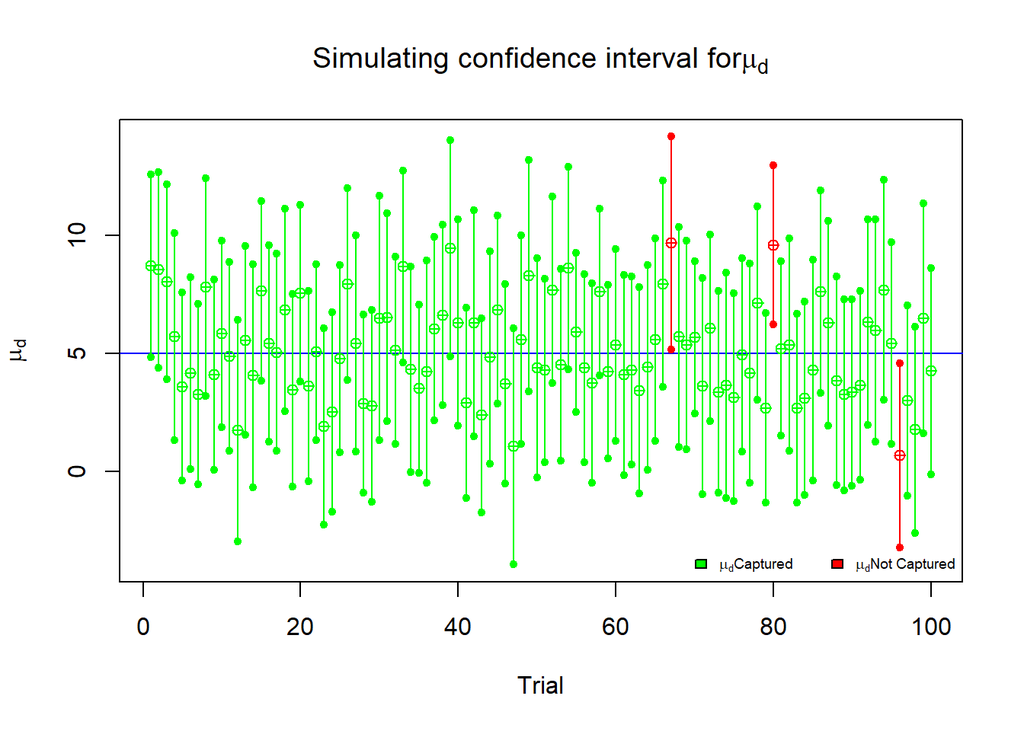

```
## $Trial
## [1] 100
##
## $Sample.Size
## [1] 30
##
## $Population.mean
## [1] 50 45
##
## $Population.sd
## [1]  5 10
##
## $Confidence
## [1] 0.95
##
## $No.Captured
## [1] 3
```

```r
Simd_CI(n=30, m=100, mu1=50 ,mu2=45, sd1=5, sd2=10, conf.level=0.95)
```